# Data Exploration

Vineet Abraham

May 16, 2015

This document will go over some of the basic functionality in R. It can be used in a couple of ways. You can press the **Knit HTML** button in the toolbar to view the entire document either in the viewer pane in the bottom-right of the RStudio interactive development environment (IDE) or in a separate HTML window. You can select the output type by pressing the down arrow to the right of the **Knit HTML** button.

[figure not shown]

You can also run through the code in this document line-by-line by pressing the **Run** button, or chunk-by-chunk by pressing the **Chunks** button in the toolbar and then selecting **Run Next Chunk**.

[figure not shown]

These tutorial documents are meant to build upon each other so please make sure to review any earlier documents prior to starting this one.

### Basic data exploration

Let’s use the car dataset from the previous tutorial.

```r
# Load the dataframe
car <- read.csv("/home/radmin/Tutorials/data_images/cardata.csv")
# Get an idea of what the data is about using the summary command.
summary(car)
```

```
##       mpg          cylinders      displacement     horsepower
##  Min.   :14.00   Min.   :4.000   Min.   :113.0   Min.   : 85.0
##  1st Qu.:14.25   1st Qu.:8.000   1st Qu.:302.5   1st Qu.:132.5
##  Median :15.00   Median :8.000   Median :345.0   Median :155.0
##  Mean   :16.61   Mean   :7.444   Mean   :335.4   Mean   :158.9
##  3rd Qu.:18.00   3rd Qu.:8.000   3rd Qu.:421.8   3rd Qu.:196.0
##  Max.   :24.00   Max.   :8.000   Max.   :455.0   Max.   :225.0
##
##      weight      acceleration      model.year     origin
##  Min.   :2372   Min.   : 8.000   Min.   :70   Min.   :1.000
##  1st Qu.:3173   1st Qu.: 9.625   1st Qu.:70   1st Qu.:1.000
##  Median :3534   Median :10.250   Median :70   Median :1.000
##  Mean   :3521   Mean   :11.250   Mean   :70   Mean   :1.111
##  3rd Qu.:3828   3rd Qu.:12.000   3rd Qu.:70   3rd Qu.:1.000
##  Max.   :4425   Max.   :16.000   Max.   :70   Max.   :3.000
##
##                         car.name
##  "amc ambassador dpl"       : 1
##  "amc hornet"               : 1
##  "amc rebel sst"            : 1
##  "buick estate wagon (sw)"  : 1
##  "buick skylark 320"        : 1
##  "chevrolet chevelle malibu": 1
##  (Other)                    :12
```

```r
str(car)
```

```
## 'data.frame':    18 obs. of  9 variables:
##  $ mpg         : int  18 15 18 16 17 15 14 14 14 15 ...
##  $ cylinders   : int  8 8 8 8 8 8 8 8 8 8 ...
##  $ displacement: int  307 350 318 304 302 429 454 440 455 390 ...
##  $ horsepower  : int  130 165 150 150 140 198 220 215 225 190 ...
##  $ weight      : int  3504 3693 3436 3433 3449 4341 4354 4312 4425 3850 ...
##  $ acceleration: num  12 11.5 11 12 10.5 10 9 8.5 10 8.5 ...
##  $ model.year  : int  70 70 70 70 70 70 70 70 70 70 ...
##  $ origin      : int  1 1 1 1 1 1 1 1 1 1 ...
##  $ car.name    : Factor w/ 18 levels "\"amc ambassador dpl\"",..: 6 5 16 3 12 10 7 15 17 1 ...
```

```r
# Check out the top 6 rows
head(car)
```

```
##   mpg cylinders displacement horsepower weight acceleration model.year
## 1  18         8          307        130   3504         12.0         70
## 2  15         8          350        165   3693         11.5         70
## 3  18         8          318        150   3436         11.0         70
## 4  16         8          304        150   3433         12.0         70
## 5  17         8          302        140   3449         10.5         70
## 6  15         8          429        198   4341         10.0         70
##   origin                    car.name
## 1      1 "chevrolet chevelle malibu"
## 2      1         "buick skylark 320"
## 3      1        "plymouth satellite"
## 4      1             "amc rebel sst"
## 5      1               "ford torino"
## 6      1          "ford galaxie 500"
```

```r
# Create a table comparing cylinders to mpg
table(car$cylinders, car$mpg)
```

```
##
##     14 15 16 17 18 21 22 24
##   4  0  0  0  0  0  0  0  1
##   6  0  0  0  0  1  1  1  0
##   8  5  5  1  1  2  0  0  0
```

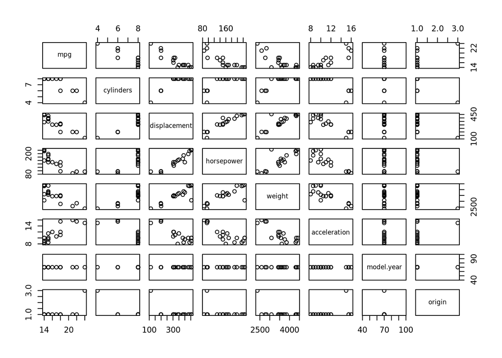

```r
# Nothing ground-breaking from the table above. We can definitely confirm that more cylinders = lower gas mileage.
# Create a scatterplot matrix of all the variables minus car.name.
pairs(car[,-which(colnames(car)=="car.name")])
```

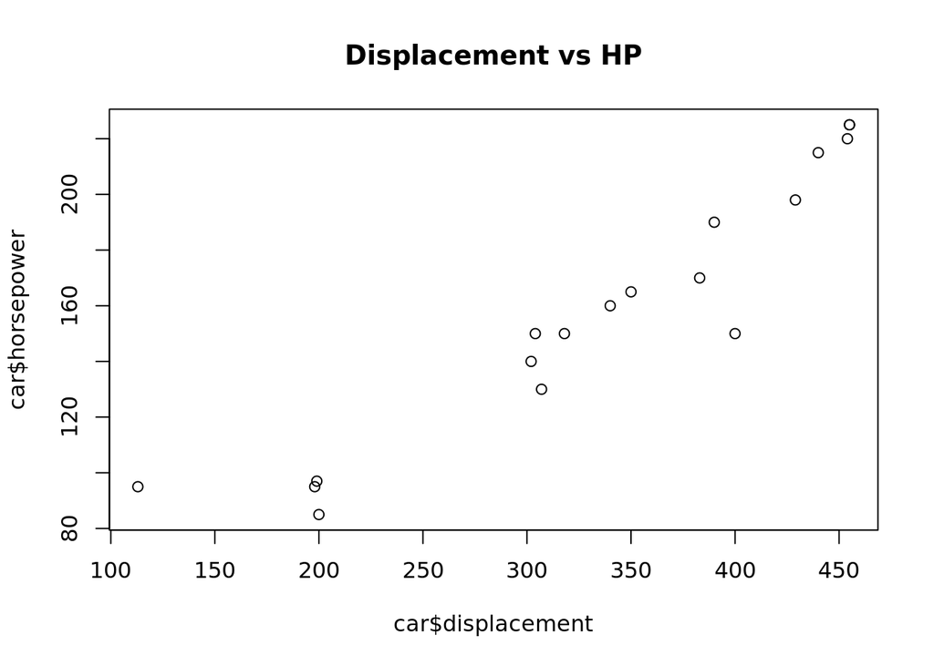

```r
# The above plot helps us see the relationships between the different variables in the dataset. Some things to notice, there is a clear positive linear relationships between displacement and horsepower, and there is a negative relationship between mpg and horsepower.
# If you want to compare two variables directly, you can use the plot() command.
plot(car$displacement, car$horsepower, main = "Displacement vs HP")
```

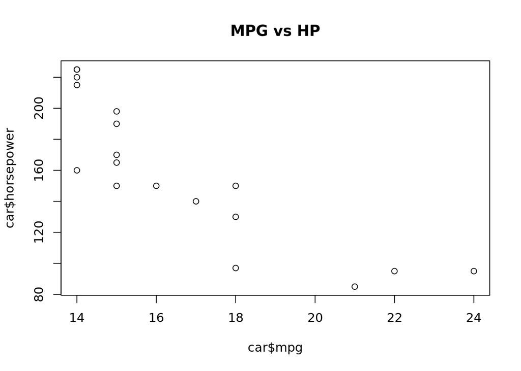

```r
plot(car$mpg, car$horsepower, main = "MPG vs HP")
```

```r
# To see the actual correlation between two variables, use the cor() command. Correlation varies from -1 (high negative correlation) to 1 (high positive correlation).
cor(car$displacement, car$horsepower)
```

```
## [1] 0.9480917
```

```r
cor(car$mpg, car$horsepower)
```

```
## [1] -0.8555032
```

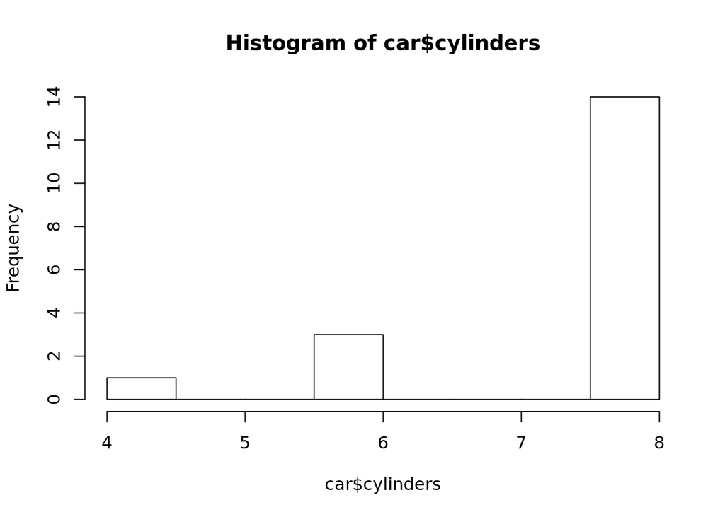

```r
# Create histograms of various car data
hist(car$cylinders)
```

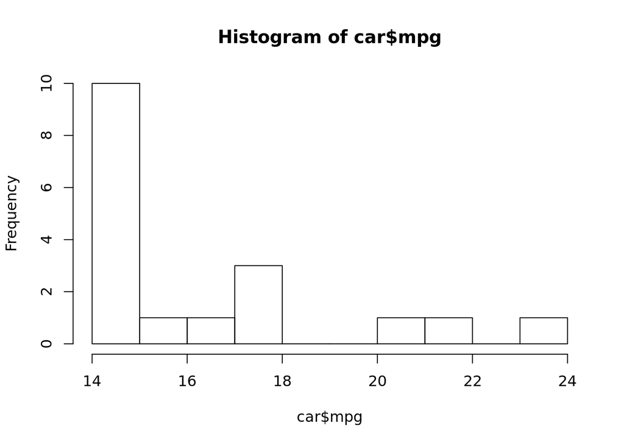

```r
hist(car$mpg, (range(car$mpg)[2]-range(car$mpg)[1]))
```

You can also add your own variables to the dataframe

```r
# Let's add a new boolean variable that indicates whether the car has 8 cylinders or not.
car$v8 <- car$cylinders >= 8
# Let's separate the car weights into 3 bins, <= 3000 is small, >= 3001 and <= 4000 is medium, and > 4000 is large.
car$weight_cat <- ifelse(car$weight<=3000, "small",
                         ifelse(car$weight<=4000, "medium", "large"))
# New variables are automatically added to the end of a dataframe.
str(car)
```

```
## 'data.frame':    18 obs. of  11 variables:
##  $ mpg         : int  18 15 18 16 17 15 14 14 14 15 ...
##  $ cylinders   : int  8 8 8 8 8 8 8 8 8 8 ...
##  $ displacement: int  307 350 318 304 302 429 454 440 455 390 ...
##  $ horsepower  : int  130 165 150 150 140 198 220 215 225 190 ...
##  $ weight      : int  3504 3693 3436 3433 3449 4341 4354 4312 4425 3850 ...
##  $ acceleration: num  12 11.5 11 12 10.5 10 9 8.5 10 8.5 ...
##  $ model.year  : int  70 70 70 70 70 70 70 70 70 70 ...
##  $ origin      : int  1 1 1 1 1 1 1 1 1 1 ...
##  $ car.name    : Factor w/ 18 levels "\"amc ambassador dpl\"",..: 6 5 16 3 12 10 7 15 17 1 ...
##  $ v8          : logi  TRUE TRUE TRUE TRUE TRUE TRUE ...
##  $ weight_cat  : chr  "medium" "medium" "medium" "medium" ...
```

### More advanced plotting with ggplot2

The ggplot2 package provides a lot of plotting functionality that is not available in standard R. We’ll go over some commands below to see a little bit of what is possible. There a lot of great resources for ggplot2 on the web, [this is one of my favorites](http://docs.ggplot2.org/current/). Some of the content below has also been borrowed from here: http://www.statmethods.net/advgraphs/ggplot2.html.

```r
# The ggplot2 package should already be installed, if not, run install.packages("ggplot2")
# Load the ggplot2 package
library(ggplot2)
# Instead of using the cars dataset, we'll use an internal R dataset called mtcars. Let's check out the dataset
?mtcars
summary(mtcars)
```

```
##       mpg             cyl             disp             hp
##  Min.   :10.40   Min.   :4.000   Min.   : 71.1   Min.   : 52.0
##  1st Qu.:15.43   1st Qu.:4.000   1st Qu.:120.8   1st Qu.: 96.5
##  Median :19.20   Median :6.000   Median :196.3   Median :123.0
##  Mean   :20.09   Mean   :6.188   Mean   :230.7   Mean   :146.7
##  3rd Qu.:22.80   3rd Qu.:8.000   3rd Qu.:326.0   3rd Qu.:180.0
##  Max.   :33.90   Max.   :8.000   Max.   :472.0   Max.   :335.0
##       drat             wt             qsec             vs
##  Min.   :2.760   Min.   :1.513   Min.   :14.50   Min.   :0.0000
##  1st Qu.:3.080   1st Qu.:2.581   1st Qu.:16.89   1st Qu.:0.0000
##  Median :3.695   Median :3.325   Median :17.71   Median :0.0000
##  Mean   :3.597   Mean   :3.217   Mean   :17.85   Mean   :0.4375
##  3rd Qu.:3.920   3rd Qu.:3.610   3rd Qu.:18.90   3rd Qu.:1.0000
##  Max.   :4.930   Max.   :5.424   Max.   :22.90   Max.   :1.0000
##        am              gear            carb
##  Min.   :0.0000   Min.   :3.000   Min.   :1.000
##  1st Qu.:0.0000   1st Qu.:3.000   1st Qu.:2.000
##  Median :0.0000   Median :4.000   Median :2.000
##  Mean   :0.4062   Mean   :3.688   Mean   :2.812
##  3rd Qu.:1.0000   3rd Qu.:4.000   3rd Qu.:4.000
##  Max.   :1.0000   Max.   :5.000   Max.   :8.000
```

```r
str(mtcars)
```

```
## 'data.frame':    32 obs. of  11 variables:
##  $ mpg : num  21 21 22.8 21.4 18.7 18.1 14.3 24.4 22.8 19.2 ...
##  $ cyl : num  6 6 4 6 8 6 8 4 4 6 ...
##  $ disp: num  160 160 108 258 360 ...
##  $ hp  : num  110 110 93 110 175 105 245 62 95 123 ...
##  $ drat: num  3.9 3.9 3.85 3.08 3.15 2.76 3.21 3.69 3.92 3.92 ...
##  $ wt  : num  2.62 2.88 2.32 3.21 3.44 ...
##  $ qsec: num  16.5 17 18.6 19.4 17 ...
##  $ vs  : num  0 0 1 1 0 1 0 1 1 1 ...
##  $ am  : num  1 1 1 0 0 0 0 0 0 0 ...
##  $ gear: num  4 4 4 3 3 3 3 4 4 4 ...
##  $ carb: num  4 4 1 1 2 1 4 2 2 4 ...
```

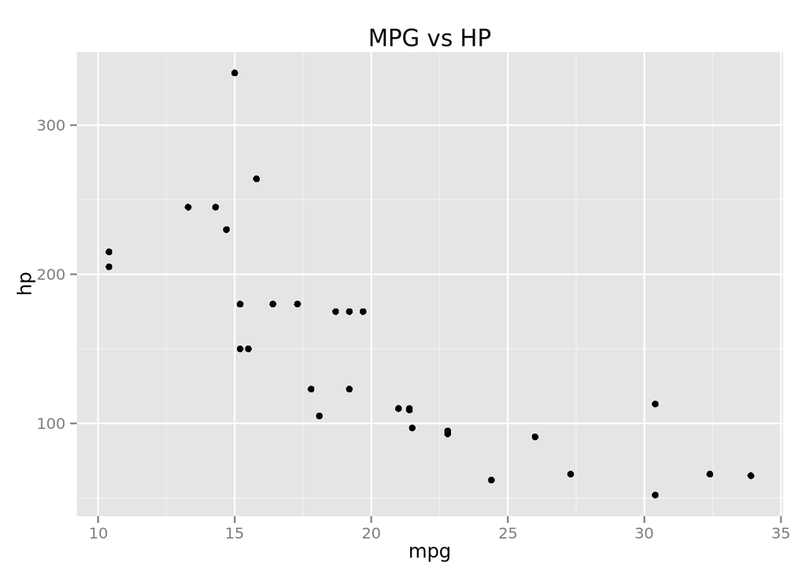

```r
# Convert some of the variables to factors
mtcars$cyl <- as.factor(mtcars$cyl)
mtcars$vs <- as.factor(mtcars$vs)
mtcars$am <- as.factor(mtcars$am)
mtcars$gear <- as.factor(mtcars$gear)
mtcars$carb <- as.factor(mtcars$carb)
# Basic dot-plots
qplot(mpg, hp, data = mtcars, main = "MPG vs HP")
```

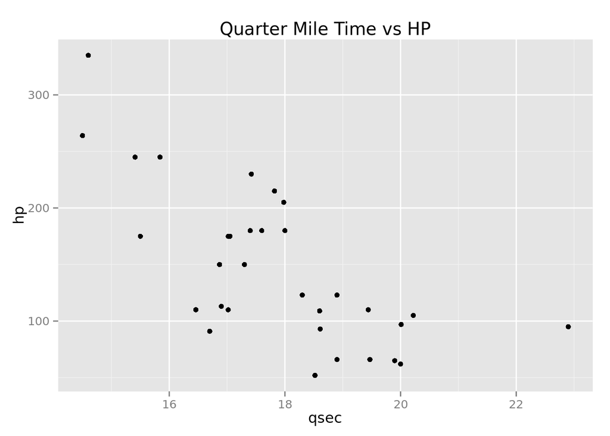

```r
qplot(qsec, hp, data = mtcars, main = "Quarter Mile Time vs HP")
```

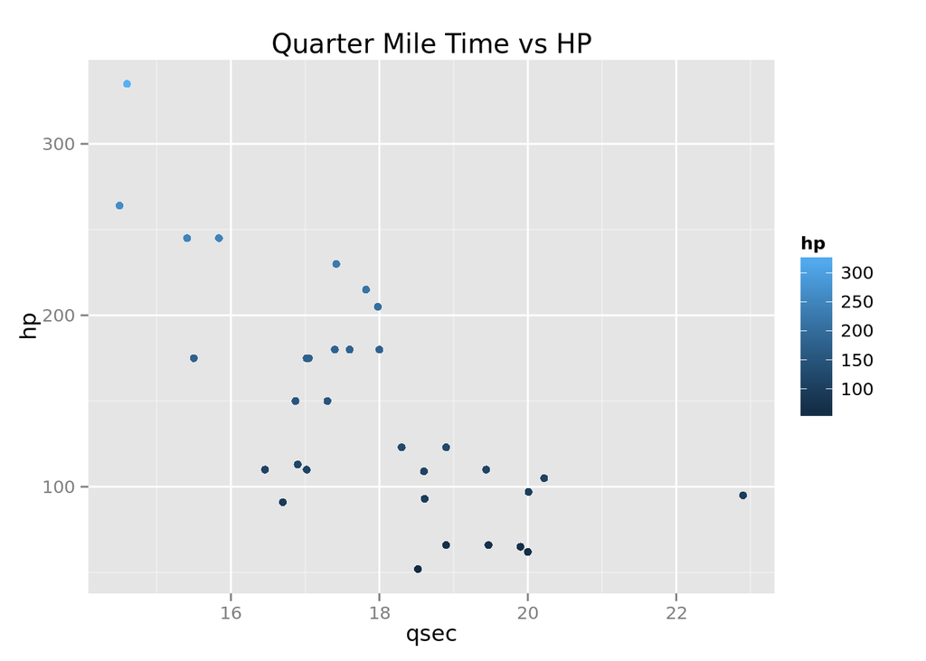

```r
# Adding color to the dot-plot for the hp variable
qplot(qsec, hp, data = mtcars, color = hp, main = "Quarter Mile Time vs HP")
```

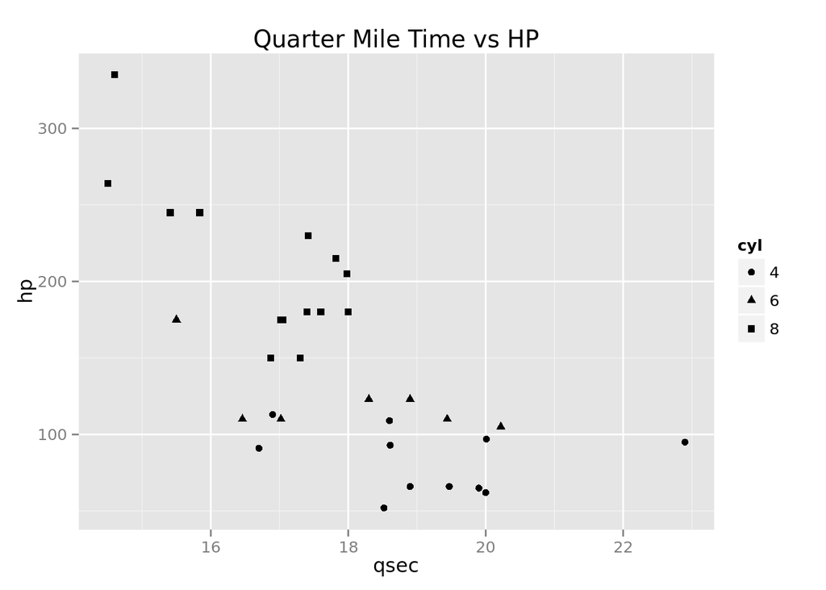

```r
# Alternating the shapes of the dot-plot data points by the variable "cyl"
qplot(qsec, hp, data = mtcars, shape = cyl, main = "Quarter Mile Time vs HP")
```

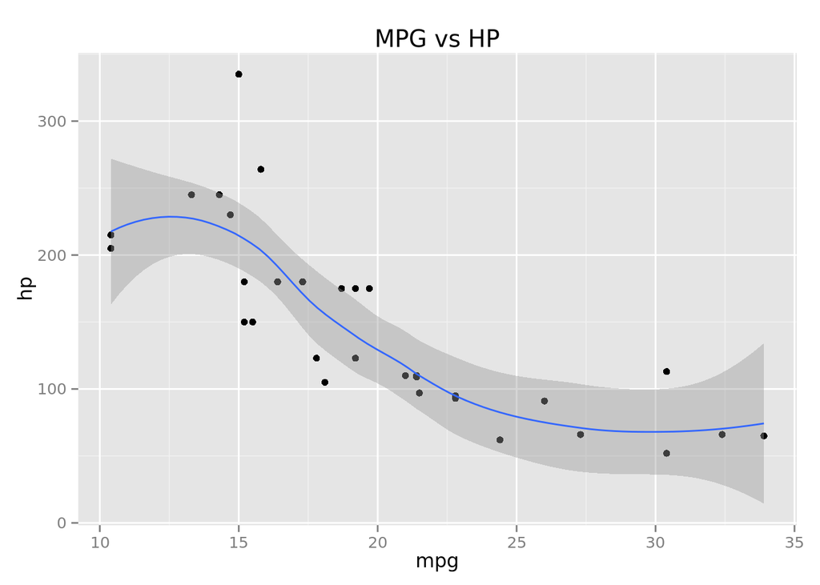

```r
# Adding a smoothing line to dot-plots
qplot(mpg, hp, data = mtcars, geom = c("point", "smooth"), main = "MPG vs HP")
```

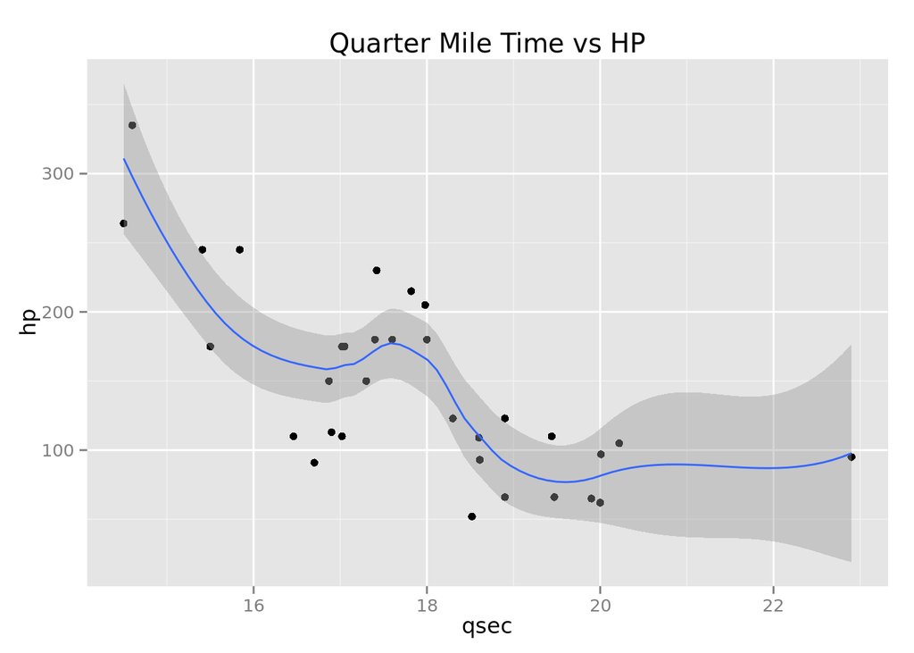

```r
qplot(qsec, hp, data = mtcars, geom = c("point", "smooth"), main = "Quarter Mile Time vs HP")
```

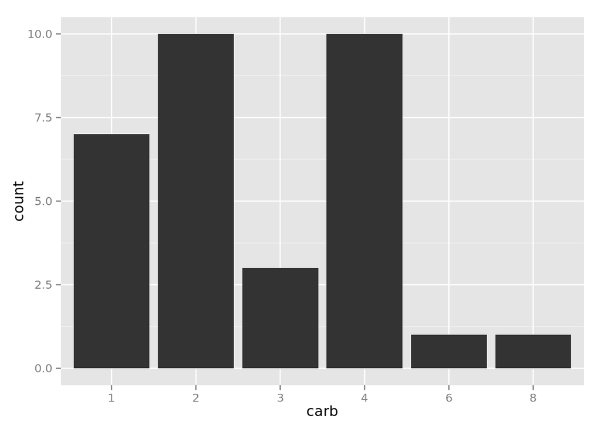

```r
# Histogram
qplot(carb, data = mtcars, geom = "histogram")
```

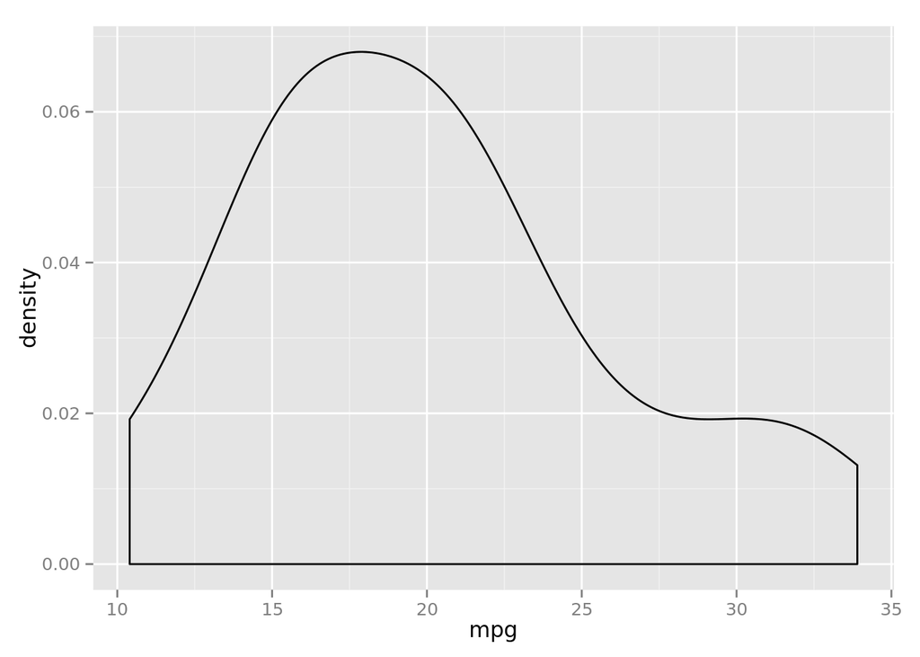

```r
# Density plot
qplot(mpg, data = mtcars, geom = "density")
```

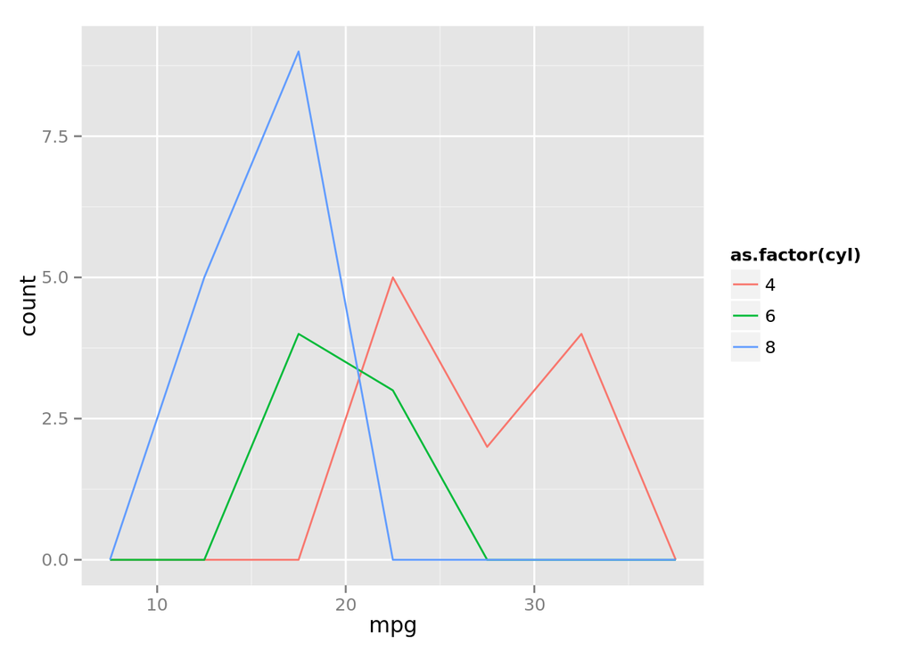

```r
# Frequency plot of mpg by number of cylinders
qplot(mpg, data = mtcars, geom = "freqpoly", binwidth = 5,
  color = as.factor(cyl))
```

The four plots below have been referenced from: http://www.statmethods.net/advgraphs/ggplot2.html.

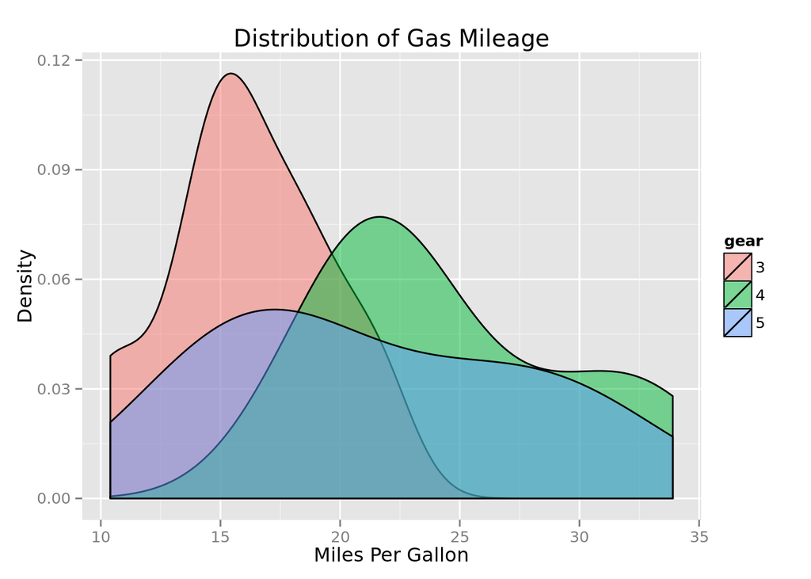

```r
# Kernel density plots for mpg grouped by number of gears (indicated by color)
qplot(mpg, data=mtcars, geom="density", fill=gear, alpha=I(.5),
   main="Distribution of Gas Mileage", xlab="Miles Per Gallon",
   ylab="Density")
```

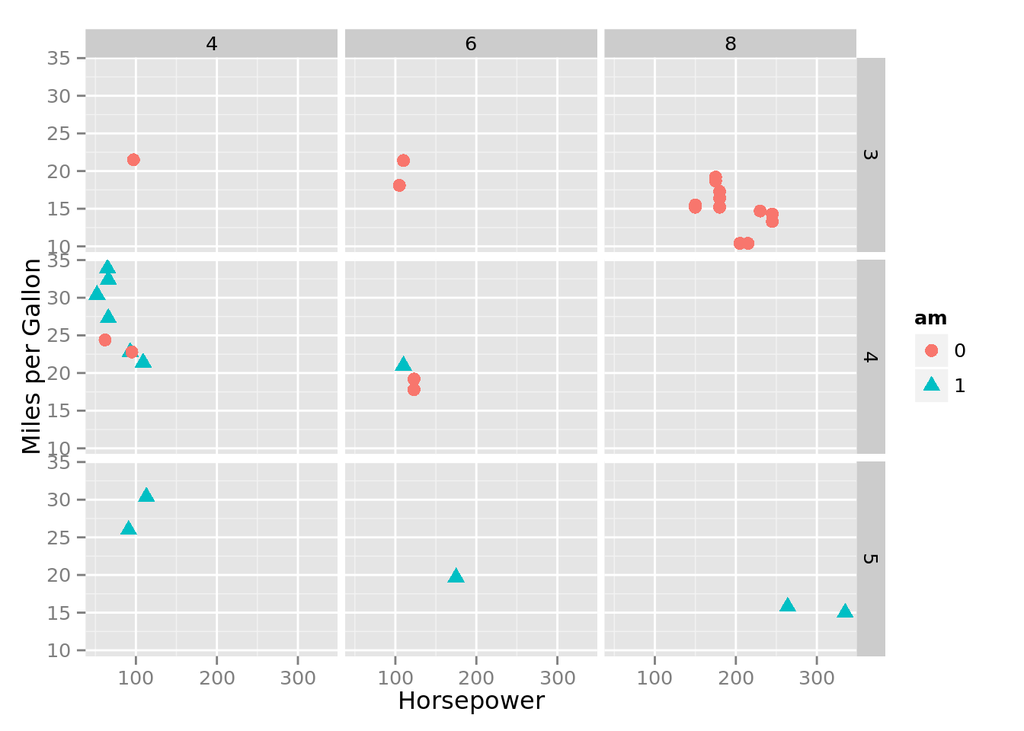

```r
# Scatterplot of mpg vs. hp for each combination of gears and cylinders in each facet, transmission type is represented by shape and color
qplot(hp, mpg, data=mtcars, shape=am, color=am,
   facets=gear~cyl, size=I(3),
   xlab="Horsepower", ylab="Miles per Gallon")
```

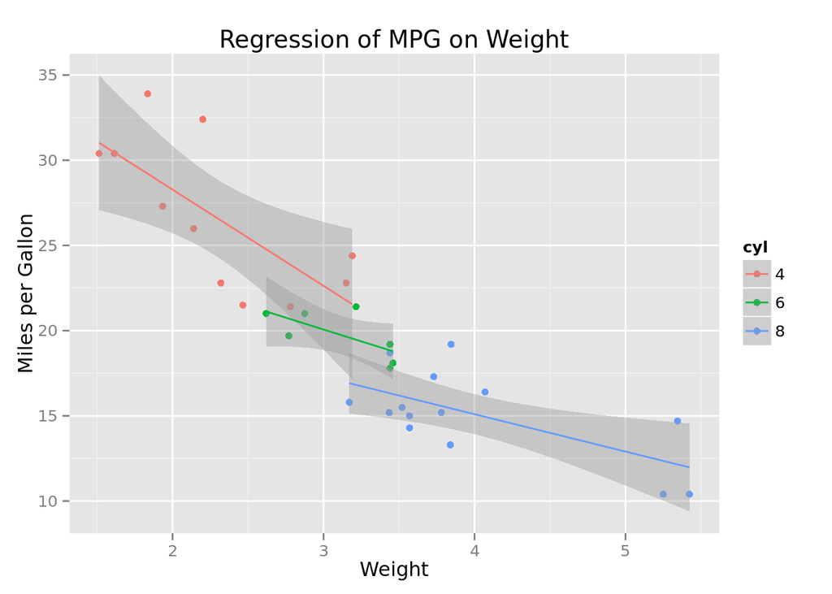

```r
# Separate regressions of mpg on weight for each number of cylinders
qplot(wt, mpg, data=mtcars, geom=c("point", "smooth"),
   method="lm", formula=y~x, color=cyl,
   main="Regression of MPG on Weight",
   xlab="Weight", ylab="Miles per Gallon")
```

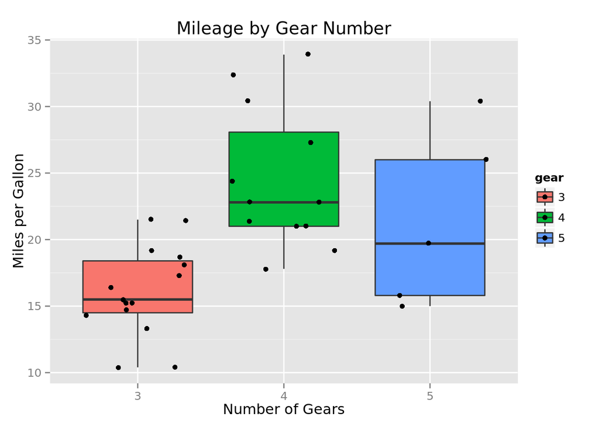

```r
# Boxplots of mpg by number of gears
# observations (points) are overlayed and jittered
qplot(gear, mpg, data=mtcars, geom=c("boxplot", "jitter"),
   fill=gear, main="Mileage by Gear Number",
   xlab="Number of Gears", ylab="Miles per Gallon")
```